# Project 1: Wrangling, Exploration, Visualization

SDS322E

## Data Wrangling, Exploration, Visualization

### Kinjal Gajera, kg28752

#### Introduction:

The two datasets I chose were USA arrests (‘USArrests’) and the average SAT results in different states (‘SAT’). The ‘USArrests’ dataset contains the types of arrests in the United States with the variables being state, murder, assault, urban pop, and rape. The ‘SAT’ dataset contains the variables: state, expend, ratio, salary, frac, verbal, math, and sat based on public schools. Both datasets contain states as the common variable. I obtained these datasets through the website provided in the instructions: https://vincentarelbundock.github.io/Rdatasets/datasets.html. These datasets were interesting to me because I noticed the difference in crime rates between the poorer neighborhood I lived in as a child and the area I l live in now. Students weren’t able to obtain a great education in underserved neighborhoods compared to students who lived in a developed area and therefore, the SAT scores would be much lower and crime rates would be much higher in poorer areas/states. I expect that if students have lower SAT scores (and therefore, higher illiteracy rates), then they will have higher crime rates and arrests.

```r
library(dplyr)
library(magrittr)
library(tidyverse)
library(grid)

arrest <- read_csv("https://vincentarelbundock.github.io/Rdatasets/csv/datasets/USArrests.csv")
sat <- read_csv("https://vincentarelbundock.github.io/Rdatasets/csv/mosaicData/SAT.csv")
```

#### Tidying: Reshaping

```r
sat2 <- subset(sat, select = -c(X1))
arrest2 <- rename(arrest, state = X1)
```

Firstly, I had to remove an unnecessary column from the ‘sat’ dataset and rename a column in the ‘arrests’ dataset so that the ‘state’ column would be exactly same in both datasets.

#### Joining/Merging

```r
joineddata <- full_join(sat2, arrest2)

nrow(sat2)
```

```
## [1] 50
```

```r
nrow(arrest2)
```

```
## [1] 50
```

```r
nrow(joineddata)
```

```
## [1] 50
```

```r
ncol(sat2)
```

```
## [1] 8
```

```r
ncol(arrest2)
```

```
## [1] 5
```

```r
ncol(joineddata)
```

```
## [1] 12
```

After cleaning the data slightly, I joined the ‘arrest2’ and ‘sat2’ datasets by state. The common variable in both datasets is necessary to join the two datasets together. I decided to use full join in order to look at the SAT scores and crime rates/arrests for each state in one dataset without any redundancy and keep all the data. No observations were dropped after joining. Originally, the ‘arrest2’ dataset had 5 variables and 50 observations whereas the SAT dataset had 8 variables and 50 observations. The joined dataset has 12 variables with 50 observations for each variable. No observations or variables were dropped after joining.

#### Wrangling

```r
joineddata %>% filter(state == "Texas") %>% glimpse()
```

```
## Rows: 1
## Columns: 12
## $ state    <chr> "Texas"
## $ expend   <dbl> 5.222
## $ ratio    <dbl> 15.7
## $ salary   <dbl> 31.223
## $ frac     <dbl> 47
## $ verbal   <dbl> 419
## $ math     <dbl> 474
## $ sat      <dbl> 893
## $ Murder   <dbl> 12.7
## $ Assault  <dbl> 201
## $ UrbanPop <dbl> 80
## $ Rape     <dbl> 25.5
```

```r
joineddata %>% arrange(desc("sat")) %>% glimpse()
```

```
## Rows: 50
## Columns: 12
## $ state    <chr> "Alabama", "Alaska", "Arizona", "Arkansas", "California", "C…
## $ expend   <dbl> 4.405, 8.963, 4.778, 4.459, 4.992, 5.443, 8.817, 7.030, 5.71…
## $ ratio    <dbl> 17.2, 17.6, 19.3, 17.1, 24.0, 18.4, 14.4, 16.6, 19.1, 16.3, …
## $ salary   <dbl> 31.144, 47.951, 32.175, 28.934, 41.078, 34.571, 50.045, 39.0…
## $ frac     <dbl> 8, 47, 27, 6, 45, 29, 81, 68, 48, 65, 57, 15, 13, 58, 5, 9, …
## $ verbal   <dbl> 491, 445, 448, 482, 417, 462, 431, 429, 420, 406, 407, 468, …
## $ math     <dbl> 538, 489, 496, 523, 485, 518, 477, 468, 469, 448, 482, 511, …
## $ sat      <dbl> 1029, 934, 944, 1005, 902, 980, 908, 897, 889, 854, 889, 979…
## $ Murder   <dbl> 13.2, 10.0, 8.1, 8.8, 9.0, 7.9, 3.3, 5.9, 15.4, 17.4, 5.3, 2…
## $ Assault  <dbl> 236, 263, 294, 190, 276, 204, 110, 238, 335, 211, 46, 120, 2…
## $ UrbanPop <dbl> 58, 48, 80, 50, 91, 78, 77, 72, 80, 60, 83, 54, 83, 65, 57, …
## $ Rape     <dbl> 21.2, 44.5, 31.0, 19.5, 40.6, 38.7, 11.1, 15.8, 31.9, 25.8, …
```

```r
joineddata %>% select("state", "sat", "Murder", "Assault") %>%
    glimpse()
```

```
## Rows: 50
## Columns: 4
## $ state   <chr> "Alabama", "Alaska", "Arizona", "Arkansas", "California", "Co…
## $ sat     <dbl> 1029, 934, 944, 1005, 902, 980, 908, 897, 889, 854, 889, 979,…
## $ Murder  <dbl> 13.2, 10.0, 8.1, 8.8, 9.0, 7.9, 3.3, 5.9, 15.4, 17.4, 5.3, 2.…
## $ Assault <dbl> 236, 263, 294, 190, 276, 204, 110, 238, 335, 211, 46, 120, 24…
```

```r
mutatedjoineddata <- joineddata %>% mutate(rapeincidence = case_when(Rape >
    30 ~ "High", Rape <= 30 ~ "Low"))

mutatedjoineddata %>% group_by(rapeincidence) %>% summarise(meansatbasedonri = mean(sat),
    n())
```

```
## # A tibble: 2 x 3
##   rapeincidence meansatbasedonri `n()`
##   <chr>                    <dbl> <int>
## 1 High                      952.     8
## 2 Low                       969.    42
```

```r
mutatedjoineddata$rapeincidence <- str_replace_all(mutatedjoineddata$rapeincidence,
    c(High = "H", Low = "L"))

mutatedjoineddata %>% group_by(rapeincidence) %>% summarise(medianbasedonverbal = median(verbal),
    n())
```

```
## # A tibble: 2 x 3
##   rapeincidence medianbasedonverbal `n()`
##   <chr>                       <dbl> <int>
## 1 H                            446.     8
## 2 L                            454     42
```

```r
mutatedjoineddata %>% summarise(sdofavgsalary = sd(salary))
```

```
## # A tibble: 1 x 1
##   sdofavgsalary
##           <dbl>
## 1          5.94
```

```r
mutatedjoineddata %>% summarise(minofmath = min(math))
```

```
## # A tibble: 1 x 1
##   minofmath
##       <dbl>
## 1       443
```

```r
mutatedjoineddata %>% summarise(maxofmurder = max(Murder))
```

```
## # A tibble: 1 x 1
##   maxofmurder
##         <dbl>
## 1        17.4
```

```r
mutatedjoineddata %>% summarise(varianceofexpend = var(expend))
```

```
## # A tibble: 1 x 1
##   varianceofexpend
##              <dbl>
## 1             1.86
```

```r
mutatedjoineddata %>% summarise(quantileofassault = quantile(Assault))
```

```
## # A tibble: 5 x 1
##   quantileofassault
##               <dbl>
## 1                45
## 2               109
## 3               159
## 4               249
## 5               337
```

```r
mutatedjoineddata %>% summarise(minofurbanpop = min(UrbanPop))
```

```
## # A tibble: 1 x 1
##   minofurbanpop
##           <dbl>
## 1            32
```

```r
mutatedjoineddata %>% summarise(maxofratio = max(ratio))
```

```
## # A tibble: 1 x 1
##   maxofratio
##        <dbl>
## 1       24.3
```

```r
mutatedjoineddata %>% summarise(meanofrape = mean(Rape))
```

```
## # A tibble: 1 x 1
##   meanofrape
##        <dbl>
## 1       21.2
```

```r
summaryfunc <- function(data) {
    result <- data$verbal + data$math
    return(result)
}
mutatedjoineddata %>% summarise(meansat = mean(summaryfunc(mutatedjoineddata)))
```

```
## # A tibble: 1 x 1
##   meansat
##     <dbl>
## 1    966.
```

```r
mutatedjoineddata %>% group_by(rapeincidence) %>% summarise(n())
```

```
## # A tibble: 2 x 2
##   rapeincidence `n()`
##   <chr>         <int>
## 1 H                 8
## 2 L                42
```

```r
untidy <- mutatedjoineddata %>% pivot_wider(names_from = "rapeincidence",
    values_from = "Rape")

tidy <- untidy %>% pivot_longer(cols = c("H", "L"), names_to = "rapeincidence",
    values_to = "Rape")

satsummary <- mutatedjoineddata %>% group_by(rapeincidence) %>%
    summarise(meansatbasedonri = mean(sat), n())

library(gt)
sat_tbl <- tibble((satsummary))
sat_tbl
```

```
## # A tibble: 2 x 3
##   rapeincidence meansatbasedonri `n()`
##   <chr>                    <dbl> <int>
## 1 H                         952.     8
## 2 L                         969.    42
```

```r
gt_tbl <- gt(sat_tbl)
gt_tbl
```

| rapeincidence | meansatbasedonri | n() |
| --- | --- | --- |
| H | 951.750 | 8 |
| L | 968.619 | 42 |

Although there was already a column for the total SAT score, I still defined my own function as ‘summaryfunc’ which gave the result as the math and verbal scores combined (total SAT score) and used it inside summarise to determine the mean total SAT score from the mutated dataset. The result was 965.92. Then, I untidied and retidied the mutated joined dataset to show the correct use of the functions pivot_wider and pivot_longer which made more columns and more rows, respectively. Additionally, I used the gt package to create a summary table of the mean SAT score based on rape incidence which also showed the number of states that had each category of high and low and the mean scores. Overall, the data was thoroughly explored and understood to gain insight on the various functions.

#### Visualizing

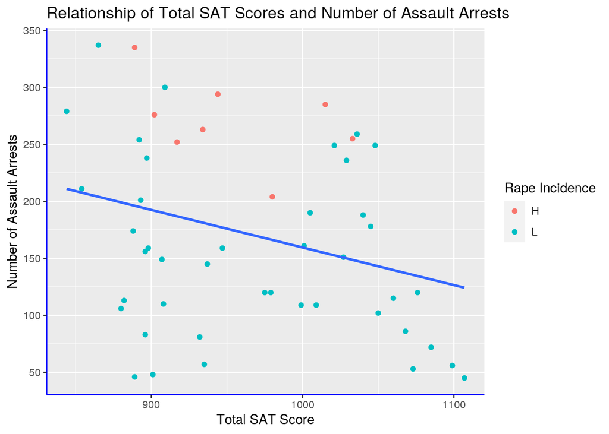

```r
ggplot(mutatedjoineddata) + geom_point(aes(sat, Assault, color = rapeincidence)) +
    geom_smooth(aes(sat, Assault), method = "lm", se = F) + xlab("Total SAT Score") +
    ylab("Number of Assault Arrests") + labs(colour = "Rape Incidence") +
    ggtitle("Relationship of Total SAT Scores and Number of Assault Arrests") +
    scale_y_continuous(breaks = seq(0, 350, 50)) + theme(axis.line = element_line(colour = "blue",
    size = 0.5, linetype = "solid"))
```

The scatterplot above displays the data for the relationship between the total average SAT scores and the number of assault arrests for every state. I labeled both the x and y axes and made a key on the right side of the scatterplot displaying that the orange color refers to a high rape incidence and the blue color refers to a low rape incidence. Based on the graph, there is a negative relationship between the two variables in which as the total SAT score increases, the number of assault arrests decreases. Essentially, a low SAT score is indirectly relates to a high illiteracy rate which is then comparable to the crime rate within each state. Based on the graph and the trendline, ss the total SAT score increases, illiteracy rate and the number of assault arrests decrease.

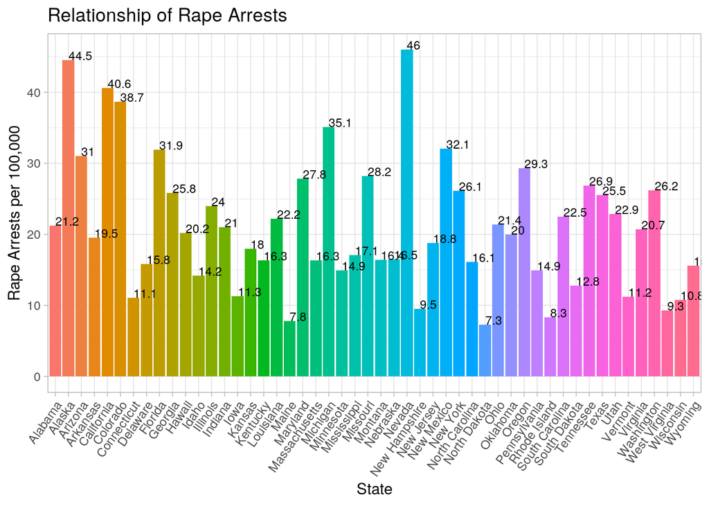

```r
ggplot(mutatedjoineddata, aes(state, Rape, fill = state)) + geom_bar(stat = "summary") +
    theme_light() + scale_y_continuous(n.breaks = 5) + theme(legend.position = "none") +
    theme(axis.text.x = element_text(angle = 55, hjust = 1)) +
    ylab("Rape Arrests per 100,000") + xlab("State") + ggtitle("Relationship of Rape Arrests") +
    geom_text(aes(label = Rape), hjust = 0, vjust = 0, size = 3)
```

The bar graph above displays the number of rape arrests per 100,000 people in each state. The text is placed on top of each bar to get the exact number of arrests when examining the data. The angle of each state on the x-axis was adjusted to fit vertically instead of being clustered horizontally. The graph shows the comparison of the number of rape arrests between all states. The states with a higher and lower number of rape arrests can easily be seen through this graph.

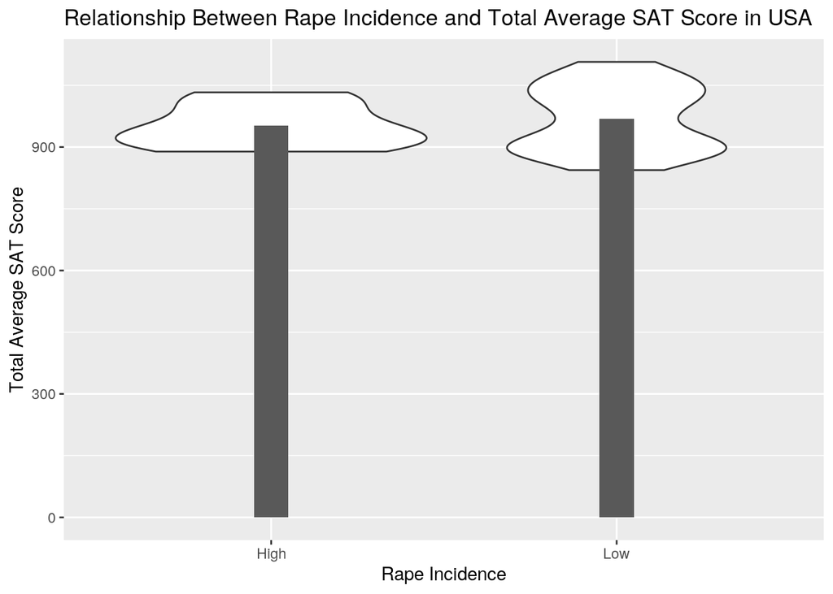

```r
ggplot(mutatedjoineddata, aes(rapeincidence, sat)) + geom_violin() +
    geom_bar(stat = "summary", width = 0.1) + theme(legend.position = "none") +
    ylab("Total Average SAT Score") + xlab("Rape Incidence") +
    ggtitle("Relationship Between Rape Incidence and Total Average SAT Score in USA") +
    scale_x_discrete(labels = c("High", "Low"))
```

The violin plot above with bars depicts the relationship between rape incidence and the total average SAT scores for all the states combined. In this case, a high rape incidence correlates to a lower total average SAT score and a higher density around the SAT score of 930. A low rape incidence correlates to a higher total average SAT score and a higher density around the SAT score of 900 and 1050. The bars display the mean SAT scores of all the states combined at a high and low rape incidence.